# Potential of Fecal Microbiota for Early-Stage Detection of Colorectal Cancer

A Differential Abundance Analysis of the ZellerG_2014 Cohort

Sally Karimi Kinyua

2026-08-12

# Background

Colorectal cancer (CRC) develops gradually, typically progressing through a precursor lesion — the **adenoma** — before becoming invasive cancer. Several bacterial taxa have been proposed as biomarkers of this progression, but their consistency across disease stages is still an active area of research.

This analysis re-examines gut microbiome composition across three stages of that progression, using shotgun metagenomic data from **Zeller *et al.*, 2014**, *“Potential of fecal microbiota for early-stage detection of colorectal cancer,”* published in *Molecular Systems Biology*.

# Research question

**Does gut microbial community composition differ between healthy controls, adenoma patients, and CRC patients — and if so, which specific taxa drive that difference?**

Three groups are compared throughout:

| Group | Description | n |
| --- | --- | --- |
| `control` | Healthy, tumour-free individuals | 61 |
| `adenoma` | Colorectal adenoma (precursor lesion) | 42 |
| `CRC` | Colorectal cancer | 53 |

`control` is used as the **reference group** throughout, so every result below is framed as “adenoma vs. healthy” or “CRC vs. healthy.”

# Analytical approach

Two complementary differential abundance methods are used:

- **ANCOM-BC2** — a compositionally-aware method that models bias directly and works on absolute count-scale data. Generally more statistically powered.
- **LEfSe** (Linear discriminant analysis Effect Size) — combines non-parametric testing (Kruskal-Wallis, Wilcoxon) with linear discriminant analysis to rank taxa by effect size. More conservative, widely used for its interpretable effect-size ranking.

Agreement between the two methods is treated as stronger evidence for a given taxon’s association with disease status.

# Data Preparation

# Identifying the dataset

The `curatedMetagenomicData` package hosts hundreds of public microbiome studies with harmonised metadata, making it possible to reproduce and extend published analyses like Zeller et al. (2014) directly.

```r
crc_related_terms <- c("CRC", "adenoma", "carcinoma_surgery_history", "control")

crc_overview <- sampleMetadata |>
  filter(study_condition %in% crc_related_terms) |>
  count(study_name, study_condition)

crc_overview
```

```
##                study_name           study_condition    n
## 1           AsnicarF_2017                   control   24
## 2           AsnicarF_2021                   control 1098
## 3           BackhedF_2015                   control  400
## 4           BedarfJR_2017                   control   28
## 5   Bengtsson-PalmeJ_2015                   control   70
## 6            BritoIL_2016                   control  312
## 7            BrooksB_2017                   control    5
## 8     Castro-NallarE_2015                   control   16
## 9             ChngKR_2016                   control   40
## 10             ChuDM_2017                   control   86
## 11          CosteaPI_2017                   control  279
## 12           DavidLA_2015                   control    9
## 13       DeFilippisF_2019                   control   97
## 14          DhakanDB_2019                   control  110
```

[output cut: 85 more lines]

`ZellerG_2014` was selected for having all three disease stages represented with reasonably balanced sample sizes. `carcinoma_surgery_history` (present only in a different study) was excluded throughout, as it reflects a distinct post-surgical population rather than a comparable disease stage.

# Confirming the sample subset

```r
single_study_name <- "ZellerG_2014"

single_meta <- sampleMetadata |>
  filter(study_name == single_study_name,
         study_condition %in% c("control", "adenoma", "CRC"))

table(single_meta$study_condition)
```

```
##
## adenoma control     CRC
##      42      61      53
```

# Downloading abundance data

`curatedMetagenomicData()` can return data on two different scales, controlled by the `counts` argument. Both are needed here, since the two downstream methods expect different input scales:

- **`counts = FALSE`** → true relative abundance (proportions, summing to ~100 per sample) — used for **quality control, diversity, and LEfSe**
- **`counts = TRUE`** → estimated read counts (scaled by sequencing depth) — used for **ANCOM-BC2**, which models count-based bias directly

```r
single_data_ra <- curatedMetagenomicData(
  "2021-03-31.ZellerG_2014.relative_abundance",
  dryrun = FALSE,
  counts = FALSE
)

single_tse_ra <- single_data_ra[[1]]
single_tse_ra <- single_tse_ra[, single_tse_ra$study_condition %in% c("control", "adenoma", "CRC")]

single_tse_ra
```

```
## class: TreeSummarizedExperiment
## dim: 652 156
## metadata(0):
## assays(1): relative_abundance
## rownames(652):
##   k__Bacteria|p__Actinobacteria|c__Actinobacteria|o__Bifidobacteriales|f__Bifidobacteriaceae|g__Bifidobacterium|s__Bifidobacterium_longum
##   k__Bacteria|p__Bacteroidetes|c__Bacteroidia|o__Bacteroidales|f__Rikenellaceae|g__Alistipes|s__Alistipes_putredinis
##   ...
##   k__Bacteria|p__Actinobacteria|c__Actinobacteria|o__Actinomycetales|f__Actinomycetaceae|g__Actinobaculum|s__Actinobaculum_massiliense
##   k__Bacteria|p__Actinobacteria|c__Coriobacteriia|o__Coriobacteriales|f__Atopobiaceae|g__Atopobium|s__Atopobium_minutum
## rowData names(7): superkingdom phylum ... genus species
## colnames(156): CCIS00146684ST-4-0 CCIS00281083ST-3-0 ...
##   CCIS98512455ST-4-0 CCIS98832363ST-4-0
## colData names(24): study_name subject_id ... fobt ajcc
## reducedDimNames(0):
## mainExpName: NULL
## altExpNames(0):
## rowLinks: a LinkDataFrame (652 rows)
## rowTree: 1 phylo tree(s) (10430 leaves)
## colLinks: NULL
## colTree: NULL
```

# Verifying the abundance scale

A quick sanity check confirms the data is on the expected proportional scale before any analysis begins.

```r
colSums(assay(single_tse_ra, "relative_abundance"))[1:5]
```

```
## CCIS00146684ST-4-0 CCIS00281083ST-3-0 CCIS02124300ST-4-0 CCIS02379307ST-4-0
##           99.14249           99.99999           99.91655           99.99125
## CCIS02856720ST-4-0
##           99.97150
```

```r
range(assay(single_tse_ra, "relative_abundance"))
```

```
## [1]  0.00000 63.40638
```

Column sums close to 100 confirm true relative abundance, not raw counts.

# Quality Control & Community Structure

# Sequencing depth consistency

Before testing for biological differences, it’s important to confirm there’s no systematic technical bias between groups — for example, one group being sequenced to a different depth than another.

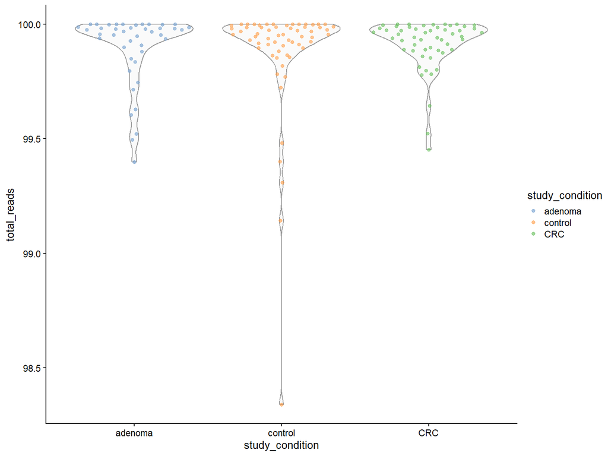

```r
colData(single_tse_ra)$total_reads <- colSums(assay(single_tse_ra, "relative_abundance"))

plotColData(
  single_tse_ra,
  y = "total_reads",
  x = "study_condition",
  colour_by = "study_condition"
)
```

All three groups cluster tightly around 100%, confirming no systematic QC bias between them.

# Alpha diversity: within-sample richness

Shannon diversity captures how evenly and richly the microbial community is represented within each individual sample.

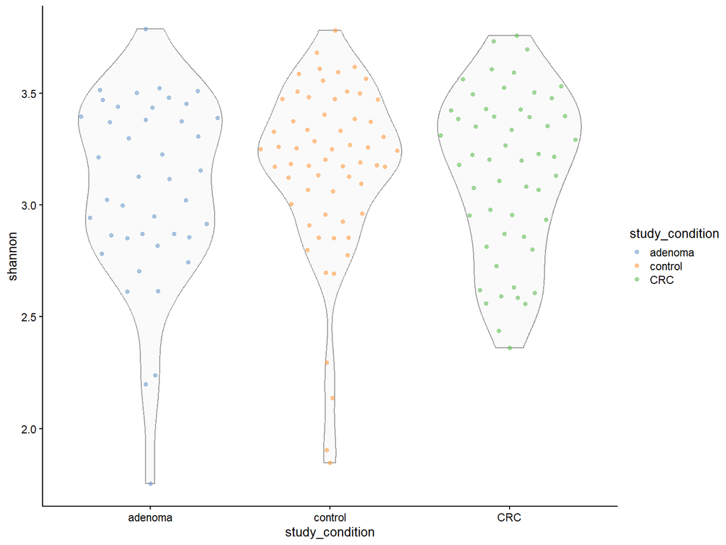

```r
single_tse_ra <- addAlpha(
  single_tse_ra,
  assay.type = "relative_abundance",
  index = "shannon"
)

plotColData(
  single_tse_ra,
  y = "shannon",
  x = "study_condition",
  colour_by = "study_condition"
)
```

Diversity is broadly similar across all three groups — consistent with the CRC literature, where disease-associated microbiome shifts are usually driven by specific taxa rather than an overall loss of diversity.

# Beta diversity: between-sample community structure

Bray-Curtis dissimilarity, visualised via Principal Coordinates Analysis (PCoA), shows whether samples cluster by disease status based on overall community composition.

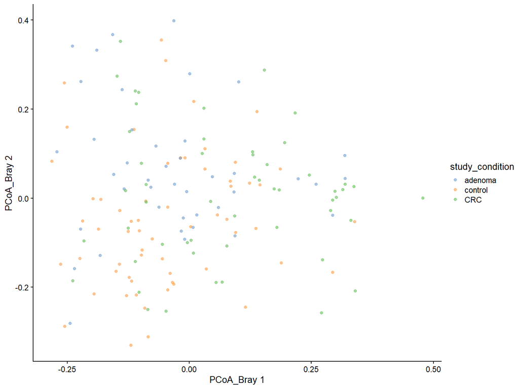

```r
single_tse_ra <- runMDS(
  single_tse_ra,
  FUN = vegan::vegdist,
  method = "bray",
  assay.type = "relative_abundance",
  name = "PCoA_Bray"
)

plotReducedDim(
  single_tse_ra,
  dimred = "PCoA_Bray",
  color_by = "study_condition"
)
```

Substantial overlap between groups — again pointing toward taxon-specific signals rather than a wholesale community shift, which is exactly what the differential abundance methods below are designed to detect.

# Differential Abundance: ANCOM-BC2

# Preparing the count-scale data

```r
single_data <- curatedMetagenomicData(
  "2021-03-31.ZellerG_2014.relative_abundance",
  dryrun = FALSE,
  counts = TRUE
)

single_tse <- single_data[[1]]
single_tse <- single_tse[, single_tse$study_condition %in% c("control", "adenoma", "CRC")]

# Set 'control' as the reference level so every comparison reads
# naturally as "vs. healthy control"
single_tse$study_condition <- factor(
  single_tse$study_condition,
  levels = c("control", "adenoma", "CRC")
)

levels(single_tse$study_condition)
```

```
## [1] "control" "adenoma" "CRC"
```

# Running ANCOM-BC2

```r
single_out <- ancombc2(
  data = single_tse,
  assay_name = "relative_abundance",
  fix_formula = "study_condition"
)

colnames(single_out$res)
```

```
##  [1] "taxon"                            "lfc_(Intercept)"
##  [3] "lfc_study_conditionadenoma"       "lfc_study_conditionCRC"
##  [5] "se_(Intercept)"                   "se_study_conditionadenoma"
##  [7] "se_study_conditionCRC"            "W_(Intercept)"
##  [9] "W_study_conditionadenoma"         "W_study_conditionCRC"
## [11] "p_(Intercept)"                    "p_study_conditionadenoma"
## [13] "p_study_conditionCRC"             "q_(Intercept)"
## [15] "q_study_conditionadenoma"         "q_study_conditionCRC"
## [17] "diff_(Intercept)"                 "diff_study_conditionadenoma"
## [19] "diff_study_conditionCRC"          "passed_ss_(Intercept)"
## [21] "passed_ss_study_conditionadenoma" "passed_ss_study_conditionCRC"
```

With three groups, the model produces two sets of coefficients — `study_conditionadenoma` and `study_conditionCRC` — each contrasted against the `control` reference.

# Results: adenoma vs. control

```r
res_adenoma_vs_control <- single_out$res %>%
  select(
    taxon,
    lfc = lfc_study_conditionadenoma,
    se = se_study_conditionadenoma,
    p_val = p_study_conditionadenoma,
    q_val = q_study_conditionadenoma,
    diff = diff_study_conditionadenoma
  ) %>%
  arrange(q_val)

sum(res_adenoma_vs_control$diff, na.rm = TRUE)  # count of significant taxa
```

```
## [1] 21
```

```r
head(res_adenoma_vs_control, 10)
```

```
##                                                                                                                                                     taxon
## 1                             k__Bacteria|p__Synergistetes|c__Synergistia|o__Synergistales|f__Synergistaceae|g__Cloacibacillus|s__Cloacibacillus_porcorum
## 2                                     k__Bacteria|p__Bacteroidetes|c__Bacteroidia|o__Bacteroidales|f__Bacteroidaceae|g__Bacteroides|s__Bacteroides_faecis
## 3                                  k__Bacteria|p__Firmicutes|c__Clostridia|o__Clostridiales|f__Ruminococcaceae|g__Ruminococcus|s__Ruminococcus_sp_CAG_403
## 4             k__Bacteria|p__Firmicutes|c__Clostridia|o__Clostridiales|f__Ruminococcaceae|g__Ruminococcaceae_unclassified|s__Ruminococcaceae_bacterium_D5
## 5                                     k__Bacteria|p__Bacteroidetes|c__Bacteroidia|o__Bacteroidales|f__Bacteroidaceae|g__Bacteroides|s__Bacteroides_nordii
## 6                                  k__Bacteria|p__Bacteroidetes|c__Bacteroidia|o__Bacteroidales|f__Bacteroidaceae|g__Bacteroides|s__Bacteroides_eggerthii
## 7  k__Bacteria|p__Firmicutes|c__Erysipelotrichia|o__Erysipelotrichales|f__Erysipelotrichaceae|g__Erysipelatoclostridium|s__Erysipelatoclostridium_ramosum
## 8                                   k__Bacteria|p__Firmicutes|c__Bacilli|o__Lactobacillales|f__Streptococcaceae|g__Streptococcus|s__Streptococcus_milleri
## 9                                     k__Bacteria|p__Bacteroidetes|c__Bacteroidia|o__Bacteroidales|f__Bacteroidaceae|g__Bacteroides|s__Bacteroides_clarus
## 10                   k__Bacteria|p__Firmicutes|c__Erysipelotrichia|o__Erysipelotrichales|f__Erysipelotrichaceae|g__Turicibacter|s__Turicibacter_sanguinis
##          lfc        se        p_val        q_val diff
## 1   3.182719 0.3005499 2.075138e-09 5.457612e-07 TRUE
## 2  -2.350956 0.3174642 2.986434e-08 7.824457e-06 TRUE
## 3   2.303344 0.3081812 3.279204e-07 8.558722e-05 TRUE
## 4   1.717229 0.2667041 3.544055e-07 9.214544e-05 TRUE
## 5  -1.713408 0.2997457 1.095371e-06 2.837011e-04 TRUE
## 6  -2.059833 0.4031884 4.354061e-06 1.123348e-03 TRUE
## 7  -1.665773 0.3361014 7.006825e-06 1.800754e-03 TRUE
## 8   1.524825 0.2623891 1.098345e-05 2.811763e-03 TRUE
## 9  -1.500747 0.3029496 1.236738e-05 3.153682e-03 TRUE
## 10 -1.556907 0.3247864 1.509729e-05 3.834711e-03 TRUE
```

**21 taxa** are significantly differentially abundant between adenoma patients and healthy controls.

# Results: CRC vs. control

```r
res_crc_vs_control <- single_out$res %>%
  select(
    taxon,
    lfc = lfc_study_conditionCRC,
    se = se_study_conditionCRC,
    p_val = p_study_conditionCRC,
    q_val = q_study_conditionCRC,
    diff = diff_study_conditionCRC
  ) %>%
  arrange(q_val)

sum(res_crc_vs_control$diff, na.rm = TRUE)  # count of significant taxa
```

```
## [1] 38
```

```r
head(res_crc_vs_control, 10)
```

```
##                                                                                                                                                                                            taxon
## 1                                                                              k__Bacteria|p__Firmicutes|c__Tissierellia|o__Tissierellales|f__Peptoniphilaceae|g__Parvimonas|s__Parvimonas_micra
## 2                                                         k__Bacteria|p__Firmicutes|c__Clostridia|o__Clostridiales|f__Peptostreptococcaceae|g__Peptostreptococcus|s__Peptostreptococcus_stomatis
## 3                                                                    k__Bacteria|p__Synergistetes|c__Synergistia|o__Synergistales|f__Synergistaceae|g__Cloacibacillus|s__Cloacibacillus_porcorum
## 4                                                                        k__Bacteria|p__Firmicutes|c__Clostridia|o__Clostridiales|f__Clostridiaceae|g__Clostridium|s__Clostridium_paraputrificum
## 5                                                            k__Bacteria|p__Firmicutes|c__Erysipelotrichia|o__Erysipelotrichales|f__Erysipelotrichaceae|g__Solobacterium|s__Solobacterium_moorei
## 6  k__Bacteria|p__Proteobacteria|c__Proteobacteria_unclassified|o__Proteobacteria_unclassified|f__Proteobacteria_unclassified|g__Proteobacteria_unclassified|s__Proteobacteria_bacterium_CAG_139
## 7                                                                               k__Bacteria|p__Firmicutes|c__Clostridia|o__Clostridiales|f__Eubacteriaceae|g__Eubacterium|s__Eubacterium_limosum
## 8                                                    k__Bacteria|p__Firmicutes|c__Clostridia|o__Clostridiales|f__Ruminococcaceae|g__Ruminococcaceae_unclassified|s__Ruminococcaceae_bacterium_D5
## 9                                                                                k__Bacteria|p__Firmicutes|c__Bacilli|o__Bacillales|f__Bacillales_unclassified|g__Gemella|s__Gemella_morbillorum
## 10                                                                           k__Bacteria|p__Firmicutes|c__Bacilli|o__Lactobacillales|f__Lactobacillaceae|g__Lactobacillus|s__Lactobacillus_sakei
##          lfc        se        p_val        q_val diff
## 1   2.671313 0.3682443 7.799467e-10 2.051260e-07 TRUE
## 2   2.879414 0.3425203 3.828289e-09 1.003012e-06 TRUE
## 3   3.005988 0.2989618 4.819506e-09 1.257891e-06 TRUE
## 4  -3.574723 0.2806450 1.018619e-08 2.648409e-06 TRUE
## 5   2.222156 0.3259521 4.347880e-08 1.126101e-05 TRUE
## 6  -2.122633 0.3591163 1.006927e-07 2.597872e-05 TRUE
## 7   2.232746 0.2831263 2.072623e-07 5.326642e-05 TRUE
## 8   2.044388 0.3171523 3.471263e-07 8.886433e-05 TRUE
## 9   1.923362 0.3109140 9.570045e-07 2.440361e-04 TRUE
## 10 -2.153641 0.2745048 2.766410e-06 7.026681e-04 TRUE
```

**38 taxa** are significantly differentially abundant between CRC patients and healthy controls — nearly double the adenoma comparison, consistent with more extensive microbial disruption at the more advanced disease stage.

# Differential Abundance: LEfSe

# A scaling note

`lefser()` internally expects abundances scaled to sum to **1,000,000** per sample (parts-per-million), a convention inherited from the original LEfSe tool. Its own `lefser:::relativeAb()` function applies this scaling correctly — general-purpose relative-abundance transforms (e.g. from `mia`, which scale to 0–1) are not equivalent here and will cause the LDA effect-size step to silently return no results.

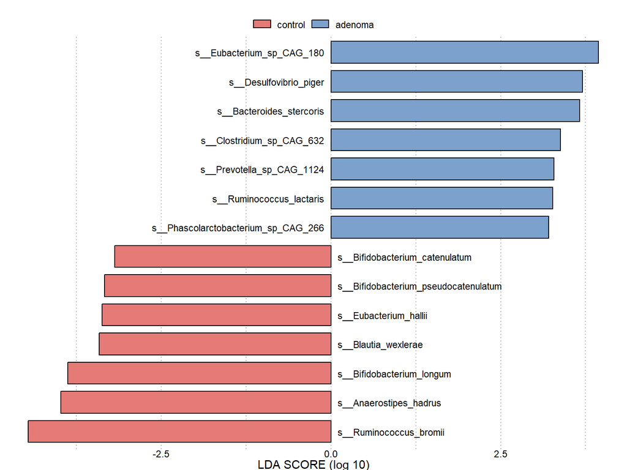

```r
single_ra_adenoma <- lefser:::relativeAb(
  single_tse[, single_tse$study_condition %in% c("control", "adenoma")]
)
single_ra_adenoma$study_condition <- droplevels(
  as.factor(single_ra_adenoma$study_condition)
)

res_lefse_adenoma <- lefser(
  single_ra_adenoma,
  classCol = "study_condition",
  lda.threshold = 3,
  trim.names = TRUE
)
lefserPlot(res_lefse_adenoma)
```

# LEfSe: CRC vs. control

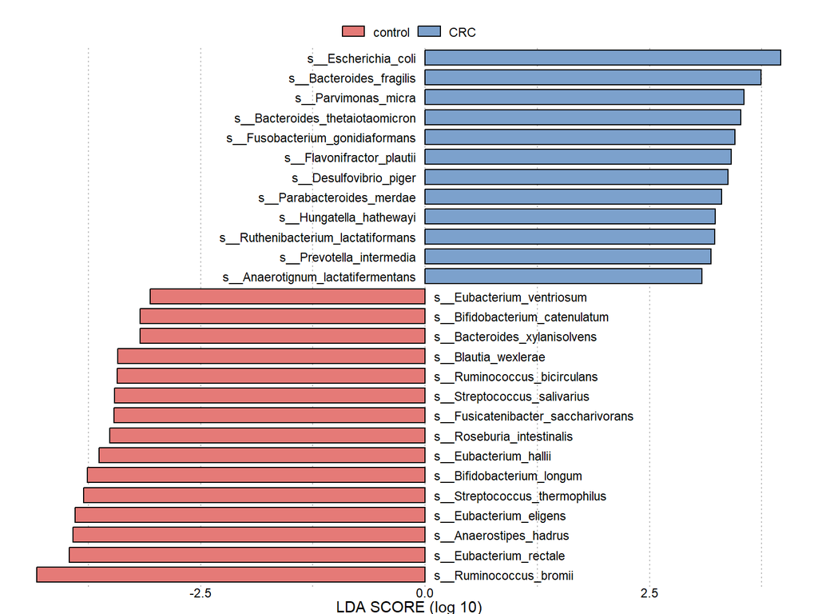

```r
single_ra_crc <- lefser:::relativeAb(
  single_tse[, single_tse$study_condition %in% c("control", "CRC")]
)
single_ra_crc$study_condition <- droplevels(
  as.factor(single_ra_crc$study_condition)
)

res_lefse_crc <- lefser(
  single_ra_crc,
  classCol = "study_condition",
  lda.threshold = 3,
  trim.names = TRUE
)
lefserPlot(res_lefse_crc)
```

Several taxa enriched in CRC here — including *Fusobacterium* and *Escherichia coli* — echo well-established findings in the CRC microbiome literature, and corroborate the ANCOM-BC2 results above using an independent statistical approach.

# Summary & Interpretation

# Key findings

- **Community-level structure** (alpha and beta diversity) does not differ dramatically across control, adenoma, and CRC — the microbiome is not globally disrupted at either disease stage.
- **Taxon-level differences are substantial**: ANCOM-BC2 identified **21 significant taxa** in adenoma vs. control and **38** in CRC vs. control, showing a clear escalation with disease progression.
- **LEfSe independently corroborates** several of the same taxa, including CRC-associated enrichment of *Fusobacterium* and *Escherichia coli* — consistent with prior literature on CRC-microbiome associations.
- Together, these results support the idea that **specific bacterial taxa, rather than overall community diversity, are the more sensitive signal** for CRC and its precursor lesions.

# Question

How can we perform a multi-group LEfSe analysis to identify differentially abundant features across the three conditions simultaneously?

# Next steps

- Extend this analysis to additional CRC cohorts (e.g. `YachidaS_2019`, `ThomasAM_2018a`, `FengQ_2015`) to test whether these taxa replicate across independent populations
- Adjust for study-level batch effects when pooling multiple cohorts
- Cross-reference significant taxa against curated microbiome signature databases (e.g. BugSigDB) for independent validation

# Thank you

**Sally Karimi Kinyua**

2026-08-12